# Chapter 5 — Normal Distributions (R companion)

R/tidyverse translation of *Understanding Data by Alan Garfinkel and Yina Guo

Adrian Soto-Mota, MD, PhD, FACP.

2026-04-24

# Orientation

Chapter 5 (book pp. 187–202) asks a deceptively simple question: **how often are real-world data actually Normal?** This companion simulates the mechanism that produces Normal data, builds a Quincunx (Galton board), and shows how to test for Normality, and reproduces the chapter’s examples of phony Normals (IQ) and mixed populations.

# §5.1 — Mechanism of the Normal *(book p. 188)*

## Flipping coins and the Central Limit Theorem

A Normal distribution arises as the **sum of many small independent random effects**. Flip a coin 100 times, count heads. Repeat 10,000 times.

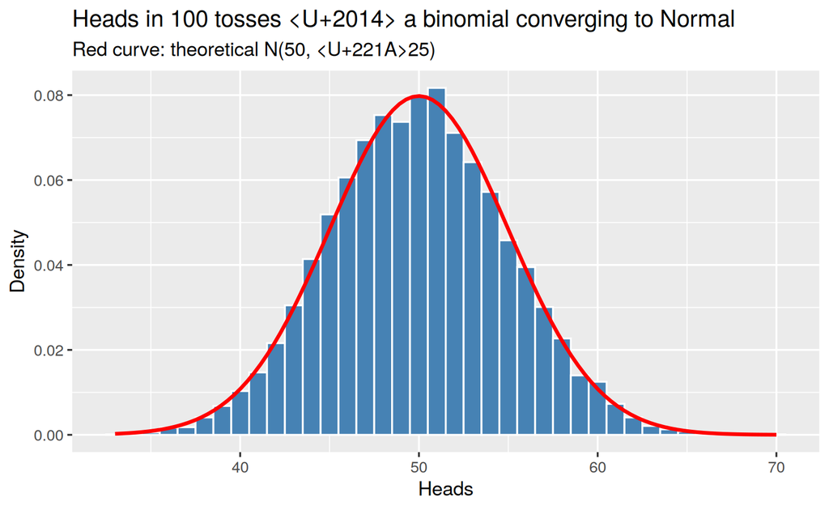

```r
n_flips    <- 100
n_trials   <- 10000
heads_count <- rbinom(n_trials, size = n_flips, prob = 0.5)

tibble(heads = heads_count) |>
  ggplot(aes(heads)) +
  geom_histogram(aes(y = after_stat(density)),
                 binwidth = 1, fill = "steelblue", color = "white") +
  stat_function(fun = dnorm,
                args = list(mean = n_flips * 0.5,
                            sd   = sqrt(n_flips * 0.25)),
                color = "red", linewidth = 1) +
  labs(title = "Heads in 100 tosses — a binomial converging to Normal",
       subtitle = "Red curve: theoretical N(50, √25)",
       x = "Heads", y = "Density")
```

The Normal shape emerges because we’re summing 100 independent ±½ contributions. This is the Central Limit Theorem in action.

## The Gaussian formula

```r
# φ(x) = (1 / (σ√(2π))) · exp(-(x-μ)² / (2σ²))
gaussian <- function(x, mu = 0, sigma = 1) {
  (1 / (sigma * sqrt(2 * pi))) *
    exp(-((x - mu)^2) / (2 * sigma^2))
}

# Check against R's built-in:
all.equal(gaussian(seq(-3, 3, 0.1)),
          dnorm(seq(-3, 3, 0.1)))
```

```
## [1] TRUE
```

## The Quincunx (Galton’s board)

Each ball falls through 20 rows of pegs; at each peg it goes left or right with probability ½. Its final bin is determined by the sum of 20 independent ±1 steps.

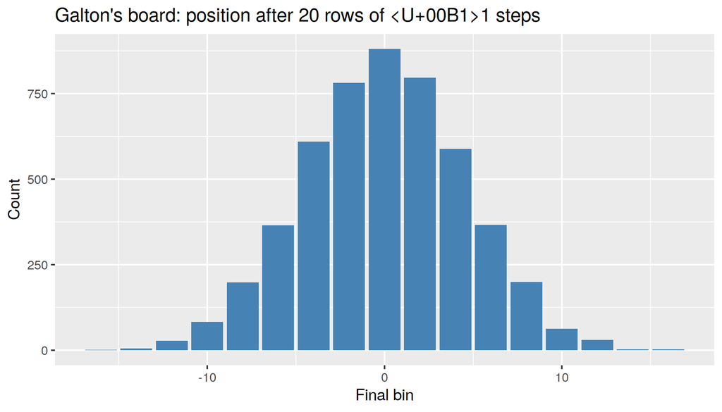

```r
n_rows  <- 20
n_balls <- 5000

final_position <- replicate(n_balls, sum(sample(c(-1, 1), n_rows, replace = TRUE)))

tibble(position = final_position) |>
  ggplot(aes(position)) +
  geom_bar(fill = "steelblue") +
  labs(title = "Galton's board: position after 20 rows of ±1 steps",
       x = "Final bin", y = "Count")
```

# §5.2 — Properties of the Normal *(book p. 192)*

## Center and spread

```r
mu    <- 100
sigma <- 15

samp <- rnorm(10000, mean = mu, sd = sigma)

# The ~68–95–99.7 rule
within_1sd <- mean(abs(samp - mu) <= 1 * sigma)
within_2sd <- mean(abs(samp - mu) <= 2 * sigma)
within_3sd <- mean(abs(samp - mu) <= 3 * sigma)
c(within_1sd = within_1sd,
  within_2sd = within_2sd,
  within_3sd = within_3sd)
```

```
## within_1sd within_2sd within_3sd
##     0.6750     0.9517     0.9971
```

## Fitting a Normal to data

```r
# "Method of moments" fit: estimate μ and σ by sample mean and SD
data_x <- c(rnorm(80, 10, 2), rnorm(20, 10, 2))  # genuinely Normal

fit_mu    <- mean(data_x)
fit_sigma <- sd(data_x)
c(fit_mu = fit_mu, fit_sigma = fit_sigma)
```

```
##    fit_mu fit_sigma
## 10.188473  2.046674
```

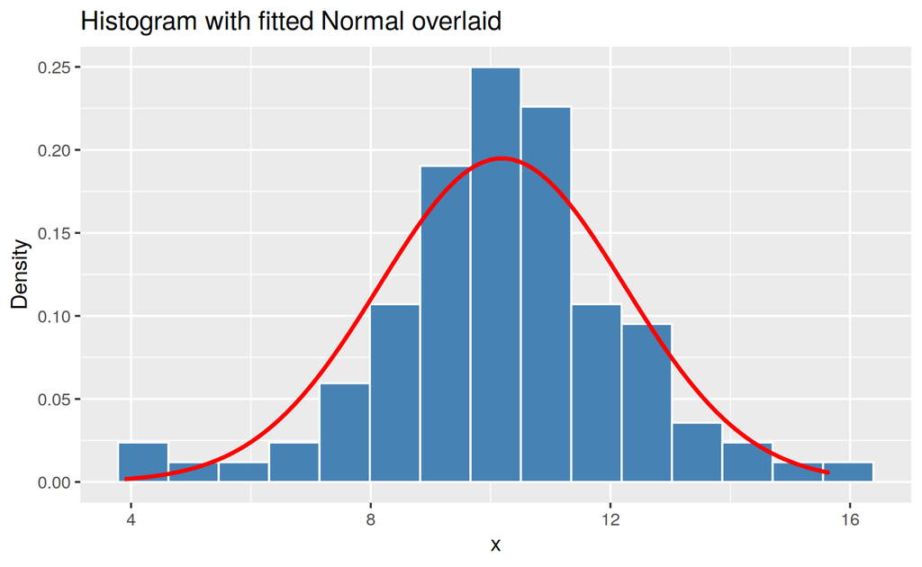

```r
tibble(x = data_x) |>
  ggplot(aes(x)) +
  geom_histogram(aes(y = after_stat(density)),
                 bins = 15, fill = "steelblue", color = "white") +
  stat_function(fun = dnorm, args = list(mean = fit_mu, sd = fit_sigma),
                color = "red", linewidth = 1) +
  labs(title = "Histogram with fitted Normal overlaid",
       x = "x", y = "Density")
```

## Testing for Normality *(book §5.2 “Testing whether a given distribution is Normal”, p. 195)*

The chapter mentions the **Shapiro-Wilk test** and **QQ plots**.

> *“[…] the Python call for a QQ plot is `sm.qqplot(data, line='45')`, then use the Python call […]”* — book p. 195

R equivalents:

```r
shapiro.test(data_x)   # H0: data come from a Normal distribution
```

```
##
##  Shapiro-Wilk normality test
##
## data:  data_x
## W = 0.98085, p-value = 0.1548
```

If p > 0.05 we **fail to reject** Normality (not the same as “it IS Normal” — see Ch. 3). For large `n`, the test becomes hypersensitive and rejects tiny, irrelevant deviations. **The chapter’s advice: trust the QQ plot, not the test.**

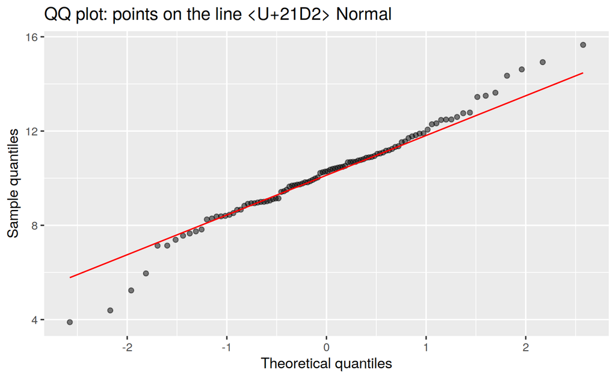

```r
tibble(x = data_x) |>
  ggplot(aes(sample = x)) +
  stat_qq(alpha = 0.5) +
  stat_qq_line(color = "red") +
  labs(title = "QQ plot: points on the line ⇒ Normal",
       x = "Theoretical quantiles", y = "Sample quantiles")
```

# §5.3 — Real-world distributions are rarely Normal *(book p. 196)*

## Mixed populations *(book §5.3, p. 196)*

Put two groups together and the Normal illusion dissolves.

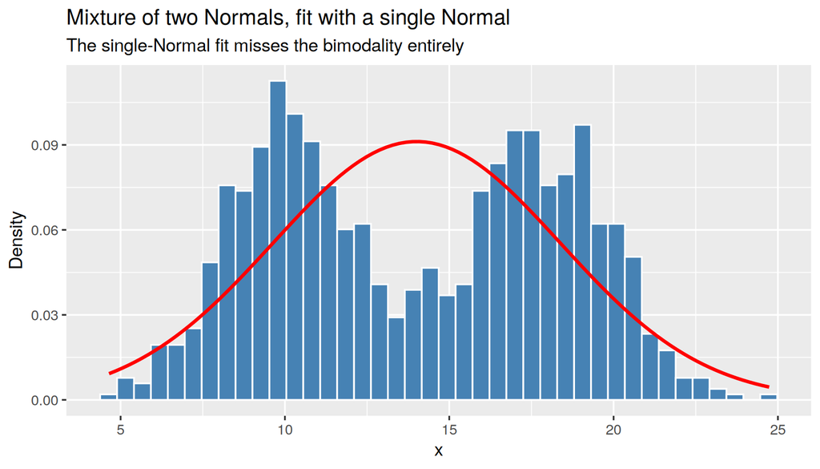

```r
mixed <- c(rnorm(500, mean = 10, sd = 2),
           rnorm(500, mean = 18, sd = 2))

tibble(x = mixed) |>
  ggplot(aes(x)) +
  geom_histogram(aes(y = after_stat(density)),
                 bins = 40, fill = "steelblue", color = "white") +
  stat_function(fun = dnorm,
                args = list(mean = mean(mixed), sd = sd(mixed)),
                color = "red", linewidth = 1) +
  labs(title = "Mixture of two Normals, fit with a single Normal",
       subtitle = "The single-Normal fit misses the bimodality entirely",
       x = "x", y = "Density")
```

```r
shapiro.test(mixed)  # correctly rejects Normality
```

```
##
##  Shapiro-Wilk normality test
##
## data:  mixed
## W = 0.953, p-value < 2.2e-16
```

## Long tails *(book §5.3, p. 198)*

Real data often have heavier tails than a Normal predicts. A Student-t with 3 df looks Normal-ish in the middle but has clear fat tails.

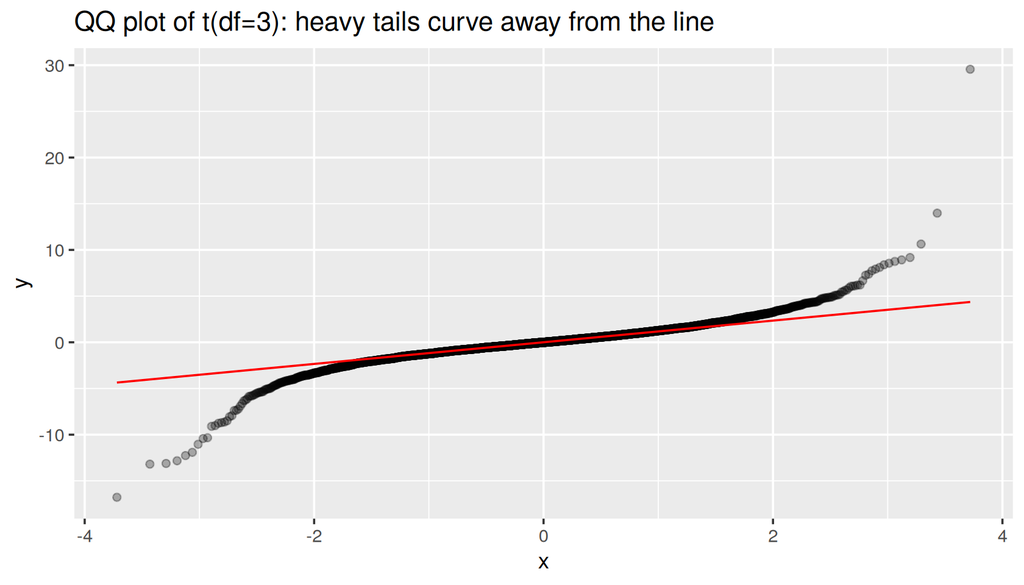

```r
heavy <- rt(5000, df = 3)

tibble(x = heavy) |>
  ggplot(aes(sample = x)) +
  stat_qq(alpha = 0.3) + stat_qq_line(color = "red") +
  labs(title = "QQ plot of t(df=3): heavy tails curve away from the line")
```

Compare how many points fall beyond ±3 SD:

```r
mean(abs(heavy - mean(heavy)) > 3 * sd(heavy))   # Much more than the 0.3% a true Normal would give
```

```
## [1] 0.0132
```

## The phony IQ Normal *(book §5.3 “Phony Normal distributions: the case of IQ”, p. 200)*

The chapter makes a striking point: IQ distributions appear Normal only because they are **constructed that way** — the test-scoring procedure forces the output onto a Normal curve. The underlying trait isn’t necessarily Normal at all.

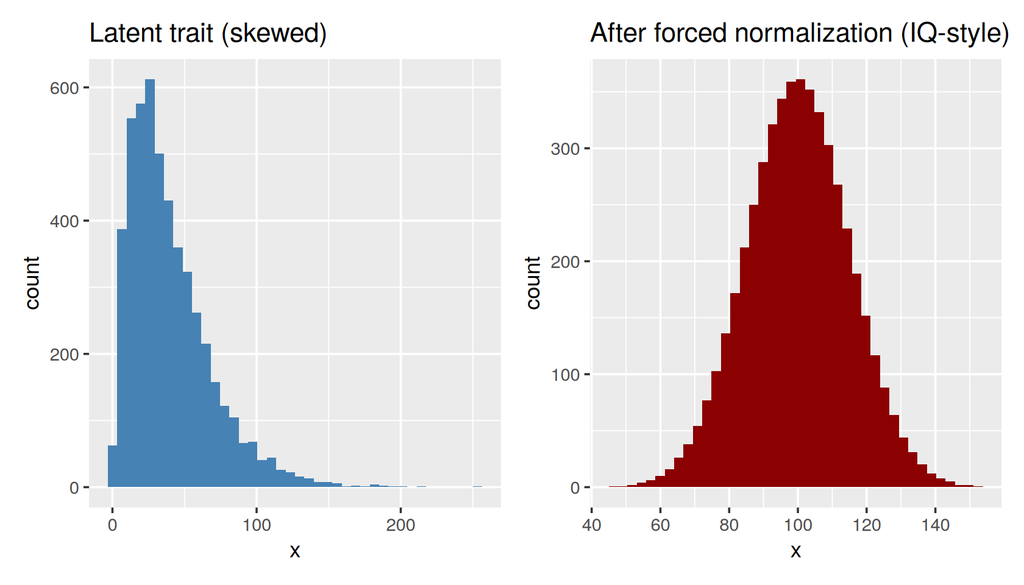

```r
# Simulate a non-Normal latent trait (skewed)
true_trait <- rgamma(5000, shape = 2, rate = 0.05)

# "Normalize" it using an inverse-CDF transform
forced_normal <- qnorm(rank(true_trait) / (length(true_trait) + 1),
                       mean = 100, sd = 15)

patchwork::wrap_plots(
  tibble(x = true_trait)   |> ggplot(aes(x)) +
    geom_histogram(fill = "steelblue", bins = 40) +
    labs(title = "Latent trait (skewed)"),
  tibble(x = forced_normal) |> ggplot(aes(x)) +
    geom_histogram(fill = "darkred", bins = 40) +
    labs(title = "After forced normalization (IQ-style)"),
  nrow = 1
)
```

The second histogram is “Normal” by construction. Any conclusion about the trait based on Normality is unfounded.

# Exercises

1. Run the coin-sum simulation with `n_flips = 2`, `5`, `20`, `100`. Plot the densities. At which `n_flips` does the shape visibly converge to Normal?
2. Apply `shapiro.test()` to `rexp(30)`, `rexp(300)`, and `rexp(3000)`. Does the p-value depend on sample size? What does that tell you about the test?
3. For the mixed example, can you fit a **mixture** of two Normals (use the `mixtools` package, `normalmixEM()`). How do the recovered means and SDs compare to the truth?